# cartopy_intro

## Cartopy in a nutshell

Cartopy is a Python package which allows the easy creation of maps, using matplotlib, for the analysis and visualisation of geospatial data.

```python
import matplotlib.pyplot as plt
import cartopy.crs as ccrs
```

Cartopy's matplotlib interface is setup via the projection keyword when constructing an Axes/SubAxes. The resulting axes instance has new methods, such as the **`coastlines()`** method which are specific to drawing cartographic type data:

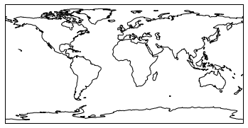

```python
ax = plt.axes(projection=ccrs.PlateCarree())
ax.coastlines()
plt.show()
```

To draw data, we use the the standard matplotlib plotting routines with an additional **transform** keyword argument. The value of the **transform** argument should be a cartopy coordinate reference system *of the data being plotted*:

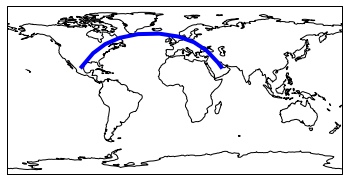

```python
ax = plt.axes(projection=ccrs.PlateCarree())
ax.coastlines()
ax.set_global()
plt.plot([-100, 50], [25, 25], linewidth=4, transform=ccrs.Geodetic())
plt.show()
```

Notice that unless we specify a map extent (we did so via the **`set_global`** method in this case) the map will zoom into the range of the plotted data.

We can add graticule lines and tick labels to the map using the gridlines method (this currently is limited to just a few coordinate reference systems):

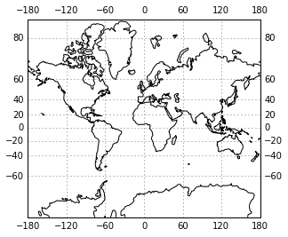

```python
ax = plt.axes(projection=ccrs.Mercator())
ax.coastlines()
gl = ax.gridlines(draw_labels=True)
plt.show()
```

We can control the specific tick values by using matplotlib's locator object, and the formatting can be controlled with matplotlib formatters:

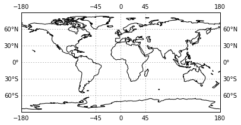

```python
import matplotlib.ticker as mticker
from cartopy.mpl.gridliner import LATITUDE_FORMATTER

ax = plt.axes(projection=ccrs.PlateCarree())
ax.coastlines()
gl = ax.gridlines(draw_labels=True)

gl.xlocator = mticker.FixedLocator([-180, -45, 0, 45, 180])
gl.yformatter = LATITUDE_FORMATTER

plt.show()
```

Cartopy cannot currently label all types of projection, though more work is intended on this functionality in the future.

**Exercise 1:**

The following snippet of code produces coordinate arrays and some data in a rotated pole coordinate system. The coordinate system for the xs and ys, which is similar to that found in the some limited area models of Europe, has a projection "north pole" at 177.5 longitude and 37.5 latitude.

```python
import numpy as np
import matplotlib.pyplot as plt
import cartopy.crs as ccrs

x = np.linspace(310, 390, 25)
y = np.linspace(-24, 25, 35)
x2d, y2d = np.meshgrid(x, y)

data = np.cos(np.deg2rad(y2d) * 4) + np.sin(np.deg2rad(x2d) * 4)
```

1. Define a cartopy coordinate reference system which represents a rotated pole with a pole latitude of 37.5 and a pole longitude of 177.5.

2. Produce a map, with coastlines, using the coordinate reference system created in #1.

3. Produce a map, with coastlines, in a Plate Carree projection with a pcolormesh of the data generated by the code snippet provided at the beginning of the example - remember the data is in the rotated coordinate system defined in #1.